# Example Notebook Explained

# Article 1: How R Notebooks Run in iMotions - An Example Notebook Explained

This article will use Skin Temperature R Notebook as an example, to explain the basics of how R Notebooks run in the iMotions platform, read user input parameters and generate results. The full notebook script can be found [here](https://github.com/imotions/R-library/blob/main/imotionsApi/example-notebooks/SkinTemperature.Rmd).

If you write your own R Notebooks that use the imotionsApi package, please note that imotionsApi is licensed under [GPL 3.0](https://github.com/imotions/R-library/blob/main/LICENSE).

## 1. Defining metadata

```yaml
title: "Skin Temperature"
description: "Computes for each respondent the calibrated skin temperature assuming amp run in DC, according to corresponding gain and chosen temperature scale."
helpUrl: https://go.imotions.com/Skin_Temperature
dependencies:
  sensor: "Biopac"
params:
  token: "xxxxx"
  studyId: "xxxxx"
  respondentId: "xxxxx"
  selectedSensorName: ""
  flowName: "xxxxx"
  iMotionsVersion: "xxxxx"
  GainSelection:
   label: "Select corresponding gain used"
   value: "1"
   selected: "1"
   input: select
   choices: ["0.5", "1", "2", "5"]
  TemperatureScaleSelection:
   label: "Choose temperature scale"
   value: "Fahrenheit (deg F)"
   selected: "Fahrenheit (deg F)"
   input: select
   choices: ["Fahrenheit (deg F)", "Celsius (deg C)"]
output:
  html_document:
    df_print: kable
    code_folding: hide
    code_download: true
```

The character string after “title”: `title: "Skin Temperature"` defines the notebook’s name shown under “Algorithm” when one adds notebook in iMotions desktop.

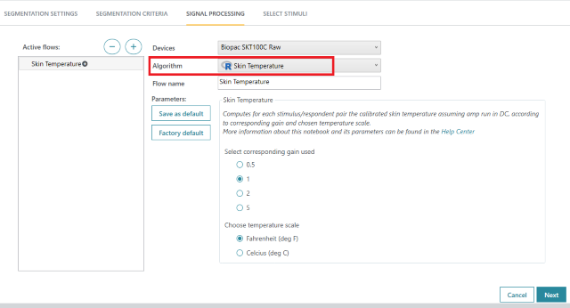

notebook’s name shown under “Algorithm”.

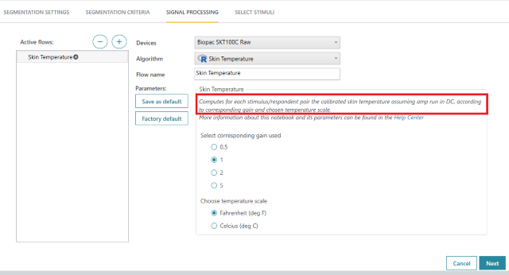

notebook’s summary.

The character string after “sensor” under “dependencies”: `sensor: "Biopac"` defines what type of sensors can be used for running this notebook.

Normally a notebook will specify a particular study to work on as part of its code. However we would like the notebook to be able to run against any study. To achieve this we use the R markdown parameters feature to set the values for the study the notebook is currently being run for. The system will assign a token, studyId, respondentId in the params block in the metadata and the notebook will run on the study and respondents that user specified in the UI when creating analysis. E.g.,

```
params:
 token: "1234-5678-9012-3456"
 studyId: "210799d9-5c1e-45e0-aaab-8271e0d2c4aa"
 respondentId: "1000"
```

R code in the rest of the notebook can then access this, E.g., `imotionsApi::imConnection(params$token)`

If your notebook takes additional parameters such as the “TemperatureScale” (Fahrenheit or Celsius) to use for Skin Temperature conversion, you can also add that to the params block, and the values of these parameters will be assigned based on the user’s choices in the UI. There are in total, five types of params variables available with iMotions desktop: select, multi-select, checkbox, text and numeric:

“Select” type in R:

```
params:
  GainSelection:
   label: "Select corresponding gain used"
   value: "1"
   selected: "1"
   input: select
   choices: ["0.5", "1", "2", "5"]
```

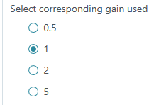

Select type in iMotions desktop.

“Multi-Select” type in R:

```
params:
 Powerbands:
   label: "Powerbands options"
   value: "Alpha"
   selected: "Alpha"
   input: select
   choices: ["Delta", "Theta", "Alpha", "Beta", "Gamma"]
   multiple: yes
```

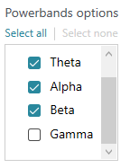

“Multi-Select” type in iMotions desktop

“Checkbox” type in R:

```
params:
  Autoflip:
   label: "Check the polarity of the signal and flip it if necessary"
   value: FALSE
   input: checkbox
```

“Text” type in R:

```
params:
 refChannel1:
   label: "Reference channel 1"
   value: "Ref"
   input: text
```

“Numeric” type in R:

```
params:
 extremethr:
   label: "Artefact threshold [in μV]"
   value: 120
   input: numeric
   min: 0
```

Please note that, using this library: when you load a signal, it will be retrieved for the entire duration of the study recording i.e., for all the stimuli.

## 2. Defining global options: packages loading

Load the packages needed for the notebook running. iMotions already has the imotionsApi R library and various third-party packages needed for released notebooks installed. If you install other packages as part of the code in your notebook, they will not work in iMotions desktop since they need to be installed from iMotions side. You can find all iMotions installed packages from here: `C:\Program Files\iMotions\Lab_XG\R\library`.

## 3. Retrieving parameters

```r
# Retrieves parameters
gain <- as.numeric(params$GainSelection)
temp_scale <- params$TemperatureScaleSelection
```

## 4. Defining functions

We are providing a set of functions that can be used across scripts, you can load them using the following chunk.

```r
# Load function common to all scripts (first look inside the same directory and if empty look inside the parent)
common_function_file <- "common_export_functions.R"

if (file.exists(common_function_file)) {
    sys.source(common_function_file, envir = knitr::knit_global())
} else {
    sys.source(dir("..", common_function_file, recursive = TRUE, full.names = TRUE), envir = knitr::knit_global())
}

# Hide code hide/show button from html report to avoid a lot of skipped lines
hideCodeButtons()
```

Define the function to retrieve skin temperature data samples for a given study and respondent from iMotions.

```r
#' Retrieve the Skin Temperature data for a given respondent.
#' The signal names are determined automatically.
#'
#' @param study An imStudy object as returned from \code{\link{imStudy}}.
#' @param respondent An imRespondent object as returned from \code{\link{getRespondents}}.
#' @param selected_sensor_name selectedSensorName from software dropdown - cloud value is "" and we use autodetection.
#'
#' @return A data.table containing the requested Skin Temperature data.
getSktData <- function(study, respondent, selected_sensor_name) {
    # Retrieves all sensors for a respondent of interest
    sensors <- getSensors(study, respondent)
    sensors <- sensors[sensor != "R Analysis" & eventSourceType == "Sensor", ]

    # in case a device has been selected, we just use this one
    if (selected_sensor_name != "") {
        device_info <- unlist(str_split(selected_sensor_name, "\\|\\|"))
        selected_sensor <- sensors[sensor == device_info[1] & name == device_info[2] & instance == device_info[3], ]

        if (nrow(selected_sensor) == 0) {
            # Handle the case where multiple stations are used with different devices (i.e. NBC lab setup)
            htmlWarning("The device selected was not found for this respondent, trying autodetection instead.")
            selected_sensor_name <- ""
        } else {
            sensors <- selected_sensor
        }
    }

    if (any(grepl("Biopac", sensors$sensor) & grepl("SKT", sensors$instance))) {
        device_type <- "Biopac"
        signal_instance <- "SKT100C"
        signal_name <- "Raw"
        skt_sensor_idx <- grepl(signal_instance, sensors$instance) & grepl("Biopac", sensors$sensor)
    } else {
        if (selected_sensor_name == "") {
            htmlError("Autodetection could not find any skin temperature sensor.")
        } else {
            htmlError("The device selected do not include any skin temperature signal.")
        }
        return(NULL)
    }

    message(paste(device_type, "identified."))

    # If more than one device has been found by autodetection, throw a warning and select the first one
    if (sum(skt_sensor_idx) > 1) {
        htmlWarning(paste("More than one", device_type, "skin temperature device is present.",
                          "Using the first one for processing."))
    }

    # Select the sensor and signals of interest
    sensor <- sensors[skt_sensor_idx, ][1, ]
    signals <- sensor$signals[[1]]
    selected_signal_names <- grep(paste(signal_name, collapse = "|"), signals, value = TRUE)

    # Retrieve the Skin Temperature data
    skt_data <- getSensorData(study, sensor, selected_signal_names)

    # Renames signal column to Volt
    names(skt_data)[2] <- "Volt"

    instance <- unique(strsplit(paste(sensor$sensor, sensor$instance, sensor$name), "\\s+")[[1]])
    attr(skt_data, "instance") <- paste(gsub(":", "", instance), collapse = " ")
    attr(skt_data, "device") <- device_type

    return(skt_data)
}
```

## 5. Connecting to iMotions

```r
# Creating connection and loading respondent
connection <- imConnection(params$token)
study <- imStudy(connection, params$studyId)
respondent <- getRespondent(study, params$respondentId)

study_name <- study$name
respondent_name <- respondent$name
```

Establish connection to iMotions API and retrieve study/analysis information (stimuli, respondents and more) by calling functions provided by `imotionsApi`.

## 6. Executing algorithms

```r
# Extracting data
skt_data <- getSktData(study, respondent, selectedSensorName)

# Converting to Fahrenheit and adjusting with corresponding gain
skt_data$`Skin Temperature` <- (skt_data$Volt * gain) + 90

# Skin temperture calculation (convertion into celcius if chosen)
if (temp_scale == "Celcius (deg C)") {
    skt_data$`Skin Temperature` <- round((skt_data$`Skin Temperature` - 30) / 2, 1)
} else {
    skt_data$`Skin Temperature` <- round(skt_data$`Skin Temperature`, 1)
}
```

The algorithms (here it’s converting raw data to temperature) are executed and results are generated.

## 7. Uploading results to iMotions for display

```r
# Creates metadata for appropriate grouping of the signal
group <- c("", "Skin Temperature")
metadata <- data.table("Provided By" = "iMotions", "Group" = group)

# Uploading the converted signals
ul_temp_signal <- uploadSensorData(params, study, skt_data, respondent, "Calibrated Skin Temperature",
                                   scriptName = "Skin Temperature", metadata)
```

After processing, upload either signals (with a Timestamp column), metrics and/or events to iMotions by calling the function `uploadSensorData`, `uploadMetrics` and/or `uploadEvents` provided by `imotionsApi`. The data then can be viewed and exported locally through the iMotions Desktop software.

## 8. Generating report

When the notebook is knitted, an HTML file (report) will be generated with specific values for parameters that the user specified when creating analysis in iMotions. The report normally includes study/analysis information, graphs/tables, algorithm descriptions and embedded R codes. In this example, the first part specifies study related information (study, respondent, sensor etc.) and is followed by algorithm descriptions.

## 9. Dropping the R file in the right path

The properly functioning .Rmd file needs to be put in the path `C:\Users\[username]\Documents\iMotions\RNotebooks` or for export files `C:\Users\[username]\Documents\iMotions\RNotebooks\Exports`, in order to be able to run in iMotions desktop. You may need to create the folders called `RNotebooks` or `Exports` yourself if they don’t exist. Please be aware that there could be repeated notebooks with the same name shown in iMotions, after your editing. We recommend that you change a notebook’s title, when you edit it.